# Modelling Peak Electricity Demand in Great Britain

Group 43, Conor McArthur sXXXXXXX, Felix Raasch s2150023 and Adam Smith s2184229

```
## [1] "/Users/adamsmith/Downloads/Statistical Computing/Group Project"
```

# Introduction

# Data description and exploratory analysis

### 2.1 Data Overview

The analysis uses two datasets provided by NESO: - **SCS_demand_modelling.csv**: Contains daily data on electricity demand, weather factors, and temporal indicators - **SCS_hourly_temp.csv**: Contains hourly temperature data for additional temperature modeling

The primary dataset includes the following key variables: - **demand_gross (MW)**: Daily peak electricity demand at 6 pm - **wind**: Estimated capacity factor of wind generation at 6 pm - **solar_S**: Estimated capacity factor of solar generation at 6 pm - **temp**: Population-weighted average temperature at 6 pm - **wdayindex**: Day of week (0-6, starting from Sunday) - **monthindex**: Month of year (0-11, starting from January) - **year**: Calendar year - **T0**: Average temperature from 3 pm-6 pm - **TE**: Average of T0 at 6 pm and TE at 6 pm on the previous day - **start_year**: Year at start of winter period - **DSN**: Number of days since November 1st

Below is a table that summarises basic information from the non-indexed variables in the dataset.

Summary Statistics of Key Variables

|  | Variable | Min | Mean | Median | Max | SD |
| --- | --- | --- | --- | --- | --- | --- |
| demand_gross | demand_gross | 32162.50 | 49294.32 | 49650.00 | 60137.50 | 5116.54 |
| wind | wind | 0.02 | 0.42 | 0.39 | 0.95 | 0.23 |
| solar_S | solar_S | 0.00 | 0.00 | 0.00 | 0.49 | 0.03 |
| temp | temp | -4.31 | 4.77 | 4.94 | 14.24 | 3.28 |
| TO | TO | -3.87 | 5.52 | 5.71 | 14.93 | 3.34 |
| TE | TE | -3.11 | 5.53 | 5.76 | 14.21 | 2.98 |

We can also crudely have a look to see how the gross demand varies over time throughout the entire dataset.

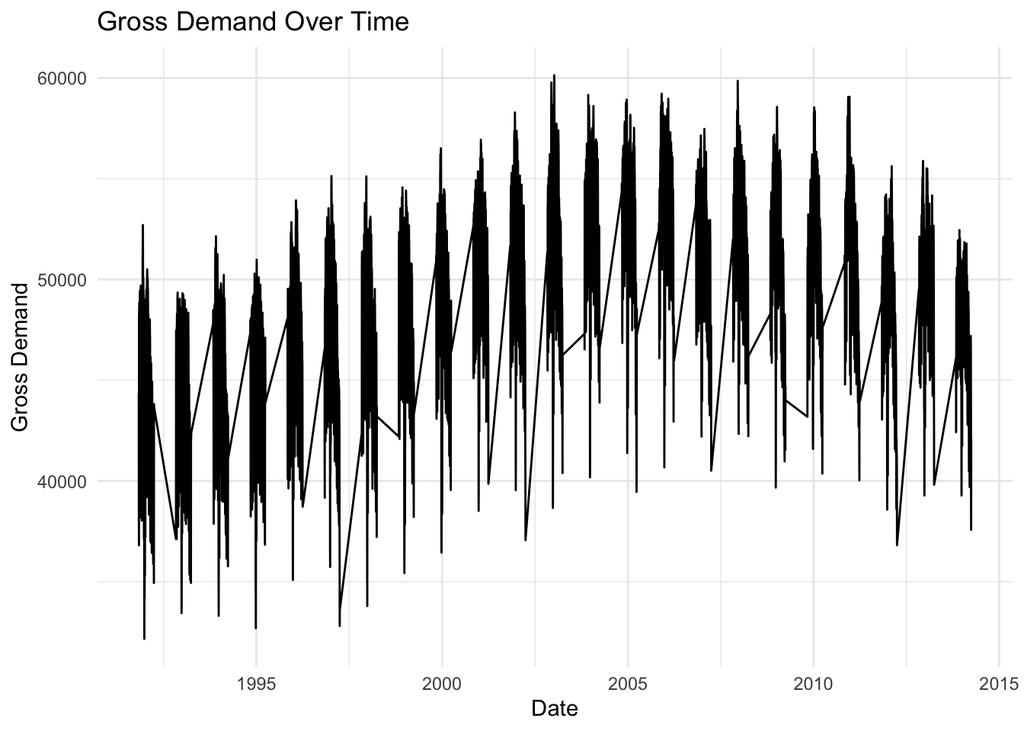

**Yearly Effect**: This plot cleary shows a trend in the yearly gross demand, rising from the 1990s until 2005 then starting to fall again. We can also see that there may be trends within each year which needs to be examined more closely.

To do that we now want to see how the gross demand varies based on our categorical variables, those that index dates.

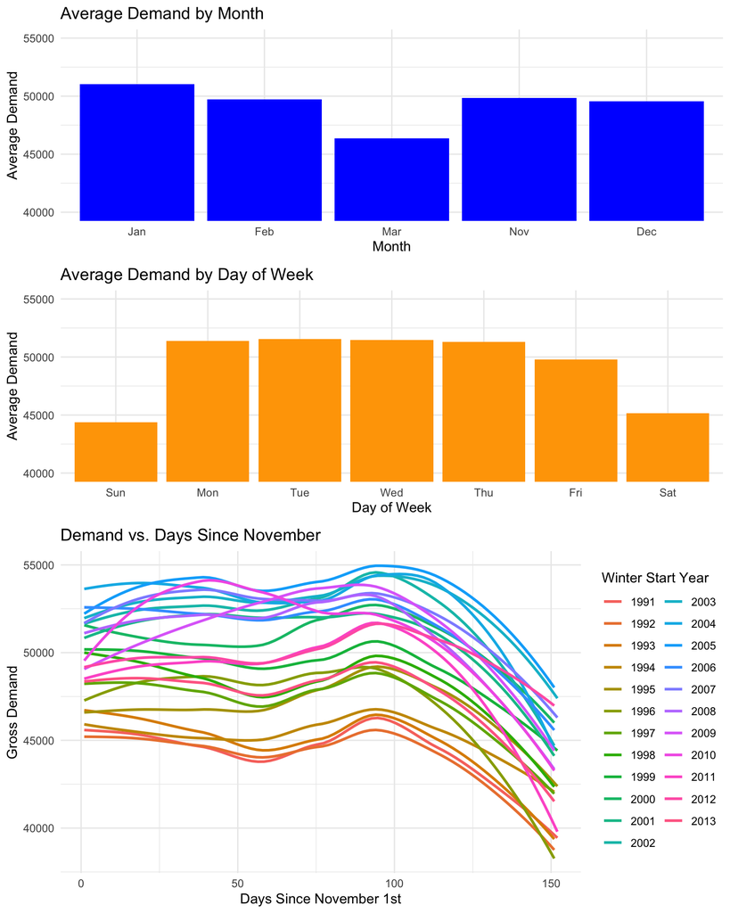

1. **Month Effect**: The first plot shows clear winter peaks rising from November to January, tapering off to lower demands in March, reflecting increased heating and lighting needs during colder months.
2. **Day-of-week effect**: Weekdays consistently show higher demand than weekends, with Friday’s demands being slightly lower than the other days in the working week. This may reflect different industrial and commercial activity levels.
3. **Intra-Year changes**: The data suggests some pattern in in peak demand as we move further away from November. These patterns seem consistent across the years, although we once again see a shift in yearly demand, whilst retaining the pattern, as seen in our first graph. This makes DSN an important variable to consider in modeling.

From these plots collectively it is clear to see that when modelling the data we want to include some temporal dependence in two ways. Firstly, the time of year, whether that is the month or using the days-since-November variabele is an important factor. Secondly, it seems we should also be including the day of the week for modelling.

### 2.3 Weather Relationship Analysis

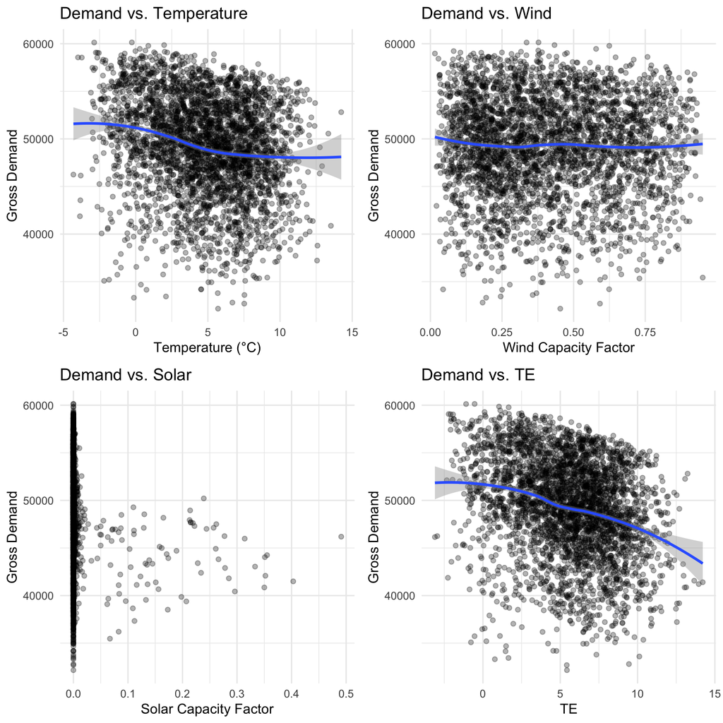

1. **Temperature Effect**: There seems to be some cubic relationship between temperature and gross electricity demand from the first graph. This is however not too convincing as seen by the wide confidence inteval in teh tails and a seemly even spread in the scatterplot.
2. **Wind Effect**: Wind seems to have very little effect on demand from the second figure which means it may not be so useful in our model.
3. **Solar Effect**: The solar effect is interesting. Many of the data-points lie about the 0 solar capacity. here the range of demands is high. The few data-points away from zero seem to be somewhat funneled, suggesting perhaps a `sqrt()` relation could be in effect, although it is difficult to be sure due to the uneven spread of data.
4. **TE Effect**: The final plot shows that perhaps using the TE to model the relationship between temperature and demand may be a more useful measure as a more clear downwards trend can be identified. Seeing how it interacts in our model will be key.

#### 3.2.1 Days Since November (DSN) Analysis

An important aspect of winter demand patterns is the progression through the winter period, captured by the DSN variable (days since November 1st). This variable will be key in modelling the demand pattern, and the below graph explores both linear and quadratic effects of DSN:

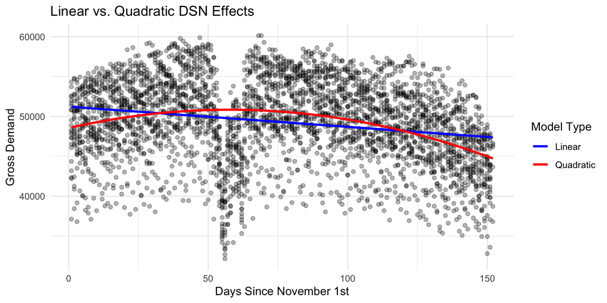

The plot does seem to suggest that a quadratic model for DSN is more appropriate, however a sharp dip at around 60 days does not fit that quadratic trend, and so seeing how including either the linear or quadratic model effect our model fit and residual plots will be key.

# Model fitting and cross-validation results

Let us first examine the suggested model:
$$M_0 : Y_i = \beta_0 + \beta_1 Wind_i + \beta_2
Solar_i + \beta_3 temp_i + \beta_4 wdayindex_i + \beta_5 monthindex_i +
\epsilon_i,\quad \epsilon_i \sim Normal(0,\sigma^2)$$
.

```
##
## Call:
## lm(formula = demand_gross ~ wind + solar_S + temp + wdayindex +
##     monthindex, data = demand_data)
##
## Residuals:
##      Min       1Q   Median       3Q      Max
## -17964.2  -2939.5    373.2   3731.8   9535.3
##
## Coefficients:
##              Estimate Std. Error t value Pr(>|t|)
## (Intercept)  50417.42     241.18 209.045  < 2e-16 ***
## wind          1244.67     398.13   3.126  0.00178 **
## solar_S     -21194.60    2932.20  -7.228 5.99e-13 ***
## temp          -356.22      27.61 -12.901  < 2e-16 ***
## wdayindex      -35.33      41.99  -0.841  0.40019
## monthindex      52.02      18.01   2.889  0.00389 **
## ---
## Signif. codes:  0 '***' 0.001 '**' 0.01 '*' 0.05 '.' 0.1 ' ' 1
##
## Residual standard error: 4952 on 3473 degrees of freedom
## Multiple R-squared:  0.06459,    Adjusted R-squared:  0.06324
## F-statistic: 47.96 on 5 and 3473 DF,  p-value: < 2.2e-16
```

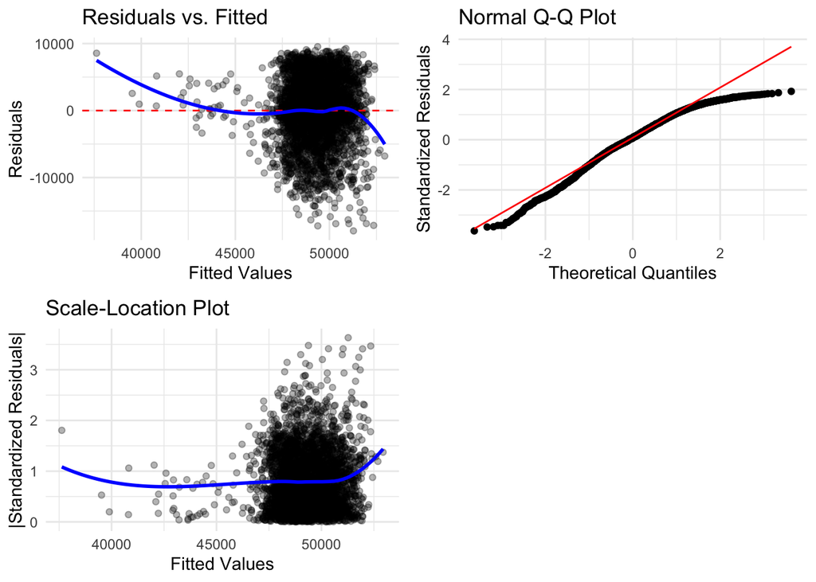

The R-squared value f this model is very low, suggesting it doesn’t explain much of the variation in data. The residual plots are extremely poor, specifically they indicate: an incorrect normality assumption of the residuals due to an extremely skewed QQ plot,especially in the upper tail; and an incorrect constant variance assumption due to the residuals not being evenly spread about zero in the residuals vs fitted plot.

Despite many of the variables being “significant” due to their p-values the poor R squared value is alarming. Oddly, the day of the week isn’t seen to be statistically significant in this model. This is strange given we saw a stark trend in our plots above.

In order to change this poor model we consider doing the following:

1. We don’t indexing time though `monthindex` variable. Instead we use the days-since-November variable (which captures seasonal trends) and the `dayindex` and `start_year` variables as factor variables to incorporate historical trends.
2. We include wind and its square to see if there are any true effects in a larger model.
3. We include solar effects and its square root, as indicated by our plot above which shows some funneling.
4. We use `TE` to model temperature as indicated by our plot which shows a clearer trend than just the `temp` variable.
5. We include interactions between `TE` and the temporal variables `DSN` and the categorical variables for the day of the week and year. This proved useful in our modelling due to how interlinked temperature is with trends in time.

To implement those trends we fit the model:
$$\begin{align}
M_1 : Y_i &= \beta_0 + \sum_{j=1}^{J} \beta_{1j} \,\text{wday}_{ij}
+ \sum_{j=1}^{J} \beta_{2j} \,\text{wday}_{ij} \cdot \text{TE}_i +
\sum_{k=1}^{K} \beta_{3k} \,\text{startyear}_{ik} + \sum_{k=1}^{K}
\beta_{4k} \,\text{startyear}_{ik} \cdot \text{TE}_i + \beta_5
\,\text{DSN}_i \\
&\quad + \beta_6 \,\text{DSN}_i^2 + \beta_7 \,\text{DSN}_i \cdot
\text{TE}_i + \beta_8 \,\text{DSN}_i^2 \cdot \text{TE}_i + \beta_9
\,\text{TE}_i + \beta_{10} \,\text{wind}_i + \beta_{11}
\,\text{wind}_i^2 + \beta_{12} \,\text{solar}_i + \beta_{13}
\,\sqrt{\text{solar}_i} + \epsilon_i,
&\quad &\epsilon_i \sim \text{Normal}(0, \sigma^2).
\end{align}$$
The model summary can be seen below.

```
##
## Call:
## lm(formula = as.formula("demand_gross ~ wday_factor + wday_factor:TE +\n                             start_year_factor + start_year_factor:TE +\n                             DSN + I(DSN^2) + DSN:TE + I(DSN^2):TE +\n                             TE + wind + I(wind^2) + solar_S + I(sqrt(solar_S))"),
##     data = demand_data)
##
## Residuals:
##      Min       1Q   Median       3Q      Max
## -15663.8   -440.8    400.5   1189.3   4952.6
##
## Coefficients:
##                            Estimate Std. Error t value Pr(>|t|)
## (Intercept)               4.408e+04  6.115e+02  72.090  < 2e-16 ***
## wday_factor1              6.486e+03  3.101e+02  20.913  < 2e-16 ***
## wday_factor2              6.694e+03  3.089e+02  21.673  < 2e-16 ***
## wday_factor3              6.793e+03  3.080e+02  22.058  < 2e-16 ***
## wday_factor4              6.747e+03  3.097e+02  21.785  < 2e-16 ***
## wday_factor5              5.528e+03  3.117e+02  17.734  < 2e-16 ***
## wday_factor6              1.032e+03  3.131e+02   3.294 0.000996 ***
## start_year_factor1992    -3.409e+03  6.015e+02  -5.668 1.56e-08 ***
## start_year_factor1993    -1.591e+03  5.725e+02  -2.779 0.005480 **
## start_year_factor1994    -6.587e+02  6.549e+02  -1.006 0.314582
## start_year_factor1995     5.797e+02  5.140e+02   1.128 0.259443
## start_year_factor1996     1.611e+03  5.194e+02   3.101 0.001941 **
## start_year_factor1997     2.820e+03  6.524e+02   4.323 1.58e-05 ***
## start_year_factor1998     3.454e+03  6.518e+02   5.300 1.23e-07 ***
## start_year_factor1999     3.637e+03  6.439e+02   5.648 1.76e-08 ***
## start_year_factor2000     4.305e+03  5.691e+02   7.566 4.93e-14 ***
## start_year_factor2001     5.101e+03  6.161e+02   8.280  < 2e-16 ***
## start_year_factor2002     8.717e+03  5.825e+02  14.964  < 2e-16 ***
## start_year_factor2003     7.862e+03  6.167e+02  12.747  < 2e-16 ***
## start_year_factor2004     8.367e+03  6.318e+02  13.241  < 2e-16 ***
## start_year_factor2005     8.264e+03  5.462e+02  15.131  < 2e-16 ***
## start_year_factor2006     6.258e+03  7.541e+02   8.299  < 2e-16 ***
## start_year_factor2007     7.448e+03  6.731e+02  11.067  < 2e-16 ***
## start_year_factor2008     6.421e+03  5.363e+02  11.974  < 2e-16 ***
## start_year_factor2009     6.252e+03  5.066e+02  12.342  < 2e-16 ***
## start_year_factor2010     6.590e+03  5.027e+02  13.110  < 2e-16 ***
## start_year_factor2011     5.503e+03  5.828e+02   9.442  < 2e-16 ***
## start_year_factor2012     5.000e+03  5.380e+02   9.295  < 2e-16 ***
## start_year_factor2013     2.736e+03  8.072e+02   3.390 0.000708 ***
```

[output cut: 28 more lines]

```
## TE:start_year_factor2007  9.852e+01  1.067e+02   0.923 0.356007
## TE:start_year_factor2008 -2.311e+01  9.096e+01  -0.254 0.799445
## TE:start_year_factor2009 -1.353e+01  8.757e+01  -0.155 0.877220
## TE:start_year_factor2010 -3.794e+01  8.568e+01  -0.443 0.657963
## TE:start_year_factor2011 -4.447e+01  8.850e+01  -0.502 0.615389
## TE:start_year_factor2012 -1.584e+02  9.918e+01  -1.597 0.110299
## TE:start_year_factor2013  1.488e+02  1.258e+02   1.183 0.236864
## TE:DSN                    6.443e+00  1.422e+00   4.531 6.07e-06 ***
## TE:I(DSN^2)              -5.860e-02  9.036e-03  -6.485 1.02e-10 ***
## ---
## Signif. codes:  0 '***' 0.001 '**' 0.01 '*' 0.05 '.' 0.1 ' ' 1
##
## Residual standard error: 2307 on 3413 degrees of freedom
## Multiple R-squared:  0.8005, Adjusted R-squared:  0.7967
## F-statistic: 210.6 on 65 and 3413 DF,  p-value: < 2.2e-16
```

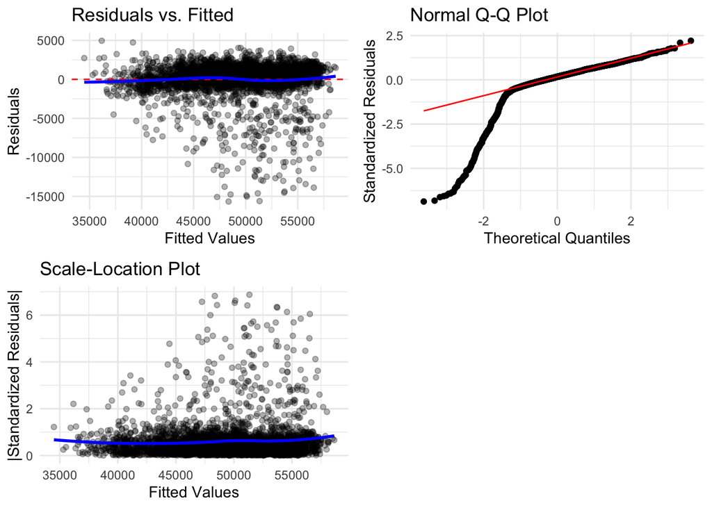

## Model Significance

Our model demonstrates a strong fit to the historical data, as reflected in an $R^2$ value of approximately 0.8. This represents a substantial improvement over the baseline model $M_0$, which achieved an $R^2$ of only around 0.065. The enhanced explanatory power of our model indicates a significantly better fit compared to $M_0$.

## Improvements

To further improve our model, we removed the variables for wind, $wind^2$, solar capacity, and the interaction between weekday and TE. This decision was informed by the low statistical significance of these variables, as indicated by their high $p$-values.

This gives us the final reduced model:
$$\begin{align}
M_1 : Y_i &= \beta_0 + \sum_{j=1}^{J} \beta_{1j} \,\text{wday}_{ij}
+ \sum_{k=1}^{K} \beta_{3k} \,\text{startyear}_{ik} + \sum_{k=1}^{K}
\beta_{4k} \,\text{startyear}_{ik} \cdot \text{TE}_i + \beta_5
\,\text{DSN}_i \\
&\quad + \beta_6 \,\text{DSN}_i^2 + \beta_7 \,\text{DSN}_i \cdot
\text{TE}_i + \beta_8 \,\text{DSN}_i^2 \cdot \text{TE}_i + \beta_9
\,\text{TE}_i + \beta_{13} \,\sqrt{\text{solar}_i} + \epsilon_i,
&\quad &\epsilon_i \sim \text{Normal}(0, \sigma^2).
\end{align}$$
The model summary can be seen below.

```
##
## Call:
## lm(formula = as.formula("demand_gross ~ wday_factor +\n                             start_year_factor + start_year_factor:TE +\n                             DSN + I(DSN^2) + DSN:TE + I(DSN^2):TE +\n                             TE +I(sqrt(solar_S))"),
##     data = demand_data)
##
## Residuals:
##      Min       1Q   Median       3Q      Max
## -15649.3   -426.3    410.4   1196.6   4565.3
##
## Coefficients:
##                            Estimate Std. Error t value Pr(>|t|)
## (Intercept)               4.376e+04  5.714e+02  76.593  < 2e-16 ***
## wday_factor1              7.127e+03  1.476e+02  48.273  < 2e-16 ***
## wday_factor2              7.288e+03  1.474e+02  49.451  < 2e-16 ***
## wday_factor3              7.207e+03  1.474e+02  48.896  < 2e-16 ***
## wday_factor4              7.007e+03  1.474e+02  47.549  < 2e-16 ***
## wday_factor5              5.567e+03  1.475e+02  37.741  < 2e-16 ***
## wday_factor6              8.141e+02  1.470e+02   5.538 3.28e-08 ***
## start_year_factor1992    -3.413e+03  6.027e+02  -5.663 1.61e-08 ***
## start_year_factor1993    -1.621e+03  5.726e+02  -2.831 0.004671 **
## start_year_factor1994    -4.958e+02  6.545e+02  -0.758 0.448793
## start_year_factor1995     7.147e+02  5.137e+02   1.391 0.164231
## start_year_factor1996     1.692e+03  5.207e+02   3.249 0.001171 **
## start_year_factor1997     2.841e+03  6.539e+02   4.345 1.43e-05 ***
## start_year_factor1998     3.418e+03  6.530e+02   5.235 1.75e-07 ***
## start_year_factor1999     3.643e+03  6.445e+02   5.652 1.72e-08 ***
## start_year_factor2000     4.363e+03  5.710e+02   7.640 2.79e-14 ***
## start_year_factor2001     5.199e+03  6.176e+02   8.419  < 2e-16 ***
## start_year_factor2002     8.785e+03  5.833e+02  15.062  < 2e-16 ***
## start_year_factor2003     7.835e+03  6.178e+02  12.681  < 2e-16 ***
## start_year_factor2004     8.415e+03  6.327e+02  13.300  < 2e-16 ***
## start_year_factor2005     8.301e+03  5.481e+02  15.146  < 2e-16 ***
## start_year_factor2006     6.115e+03  7.562e+02   8.087 8.43e-16 ***
## start_year_factor2007     7.523e+03  6.751e+02  11.143  < 2e-16 ***
## start_year_factor2008     6.496e+03  5.373e+02  12.090  < 2e-16 ***
## start_year_factor2009     6.302e+03  5.078e+02  12.411  < 2e-16 ***
## start_year_factor2010     6.647e+03  5.037e+02  13.197  < 2e-16 ***
## start_year_factor2011     5.616e+03  5.839e+02   9.618  < 2e-16 ***
## start_year_factor2012     5.117e+03  5.388e+02   9.497  < 2e-16 ***
## start_year_factor2013     2.763e+03  8.090e+02   3.415 0.000644 ***
```

[output cut: 19 more lines]

```
## start_year_factor2007:TE  9.659e+01  1.069e+02   0.904 0.366206
## start_year_factor2008:TE -2.583e+01  9.103e+01  -0.284 0.776599
## start_year_factor2009:TE -1.455e+01  8.771e+01  -0.166 0.868294
## start_year_factor2010:TE -4.406e+01  8.560e+01  -0.515 0.606782
## start_year_factor2011:TE -5.437e+01  8.849e+01  -0.614 0.538959
## start_year_factor2012:TE -1.718e+02  9.929e+01  -1.730 0.083734 .
## start_year_factor2013:TE  1.553e+02  1.259e+02   1.233 0.217669
## TE:DSN                    6.944e+00  1.418e+00   4.896 1.03e-06 ***
## TE:I(DSN^2)              -6.246e-02  8.981e-03  -6.955 4.20e-12 ***
## ---
## Signif. codes:  0 '***' 0.001 '**' 0.01 '*' 0.05 '.' 0.1 ' ' 1
##
## Residual standard error: 2316 on 3422 degrees of freedom
## Multiple R-squared:  0.7984, Adjusted R-squared:  0.7951
## F-statistic:   242 on 56 and 3422 DF,  p-value: < 2.2e-16
```

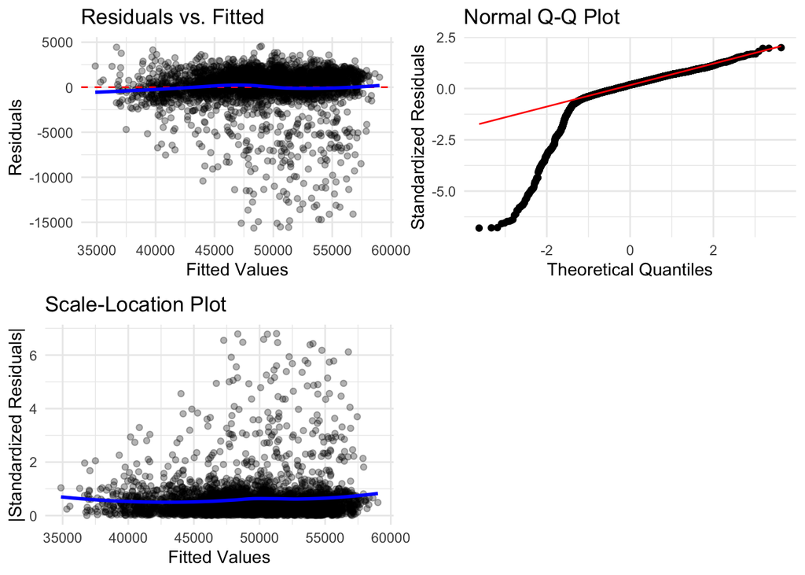

## Residual Plots Analysis

After removing the specified variables, our residual plots are broadly similar to the last model.